# Dengesizlik Yönü Tahmini

# 1. Veri Toplama

## 1.1. Kütüphanelerin içe Aktarılması

```python
import requests
import pandas as pd
from datetime import timedelta
from sklearn.metrics import accuracy_score
import numpy as np
from datetime import datetime
import datetime as dt
import json

import matplotlib.pyplot as plt
import seaborn as sns

from bs4 import BeautifulSoup
```

## 1.2. EPİAŞ'tan Veri Çekme

EPİAŞ API servisi kullanılarak belirtilen tarih aralığındaki verilerin çekilmesi.

```python
url = "https://seffaflik.epias.com.tr/transparency/service/market/smp?endDate=2022-12-31&startDate=2022-01-01"
response = requests.get(url)
data = response.json()
```

## 1.3. Veriyi Pandas DataFrame'e Dönüştürme

Çeşitli ön işlemelerin yapılması için verinin pandas DataFrame formatına dönüştürülmesi.

```python
smp_list = data['body']["smpList"]
df = pd.DataFrame(smp_list)
df["date"] = pd.to_datetime(df["date"], format="%Y-%m-%d %H:%M")
```

```python
df.head()
```

|  | date | price | smpDirection | smpDirectionId | nextHour |
| --- | --- | --- | --- | --- | --- |
| 0 | 2022-01-01 00:00:00+03:00 | 525.00 | YAT | 3 | 2022-01-01T01:00:00.000+0300 |
| 1 | 2022-01-01 01:00:00+03:00 | 848.01 | YAL | 1 | 2022-01-01T02:00:00.000+0300 |
| 2 | 2022-01-01 02:00:00+03:00 | 990.00 | YAL | 1 | 2022-01-01T03:00:00.000+0300 |
| 3 | 2022-01-01 03:00:00+03:00 | 500.00 | YAT | 3 | 2022-01-01T04:00:00.000+0300 |
| 4 | 2022-01-01 04:00:00+03:00 | 500.00 | YAT | 3 | 2022-01-01T05:00:00.000+0300 |

```python
df.info()
```

```
<class 'pandas.core.frame.DataFrame'>
RangeIndex: 8760 entries, 0 to 8759
Data columns (total 5 columns):
 #   Column          Non-Null Count  Dtype
---  ------          --------------  -----
 0   date            8760 non-null   datetime64[ns, pytz.FixedOffset(180)]
 1   price           8760 non-null   float64
 2   smpDirection    8760 non-null   object
 3   smpDirectionId  8760 non-null   int64
 4   nextHour        8760 non-null   object
dtypes: datetime64[ns, pytz.FixedOffset(180)](1), float64(1), int64(1), object(2)
memory usage: 342.3+ KB
```

```python
df.describe()
```

|  | price | smpDirectionId |
| --- | --- | --- |
| count | 8760.000000 | 8760.000000 |
| mean | 2548.647017 | 1.389269 |
| std | 1269.177221 | 0.779093 |
| min | 0.000000 | 1.000000 |
| 25% | 1524.000000 | 1.000000 |
| 50% | 2450.000000 | 1.000000 |
| 75% | 3503.000000 | 1.000000 |
| max | 4800.000000 | 3.000000 |

Price değişkeni normal dağılıyor gibi görülmektedir

```python
df.isna().sum()
```

```
date              0
price             0
smpDirection      0
smpDirectionId    0
nextHour          0
dtype: int64
```

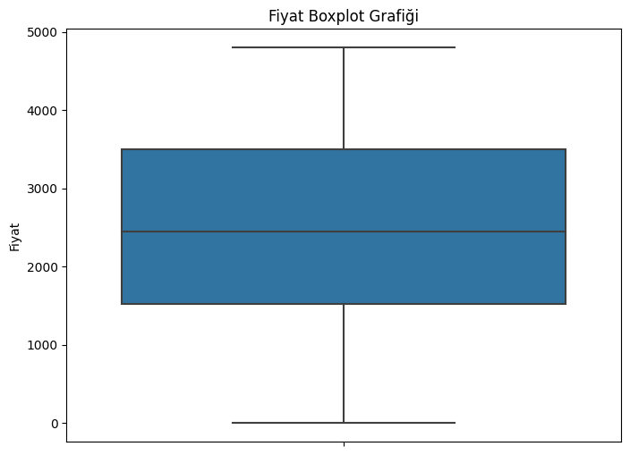

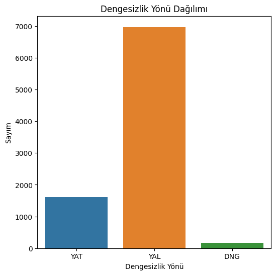

```python
# 3. Boxplot Grafiği
plt.figure(figsize=(8, 6))
sns.boxplot(y='price', data=df)
plt.ylabel('Fiyat')
plt.title('Fiyat Boxplot Grafiği')
plt.show()


# Dengesizlik Yönü Dağılımı
plt.figure(figsize=(6, 6))
sns.countplot(x="smpDirection", data=df)
plt.title("Dengesizlik Yönü Dağılımı")
plt.xlabel("Dengesizlik Yönü")
plt.ylabel("Sayım")
plt.show()
```

##### Fiyat Dağılımı

Fiyatların boxplot grafiği, fiyatların dağılımının normal olduğunu göstermektedir. Ayrıca aykırı değerlerin olmadığını da görebiliyoruz.

##### Dengesizlik Yönü Dağılımı

Dengesizlik yönü dağılımı grafiği, YAL dengesizlik yönünün en yaygın olduğunu, YAT'ın daha az yaygın olduğunu ve DNG sınıfının ise çok nadir olduğunu göstermektedir.

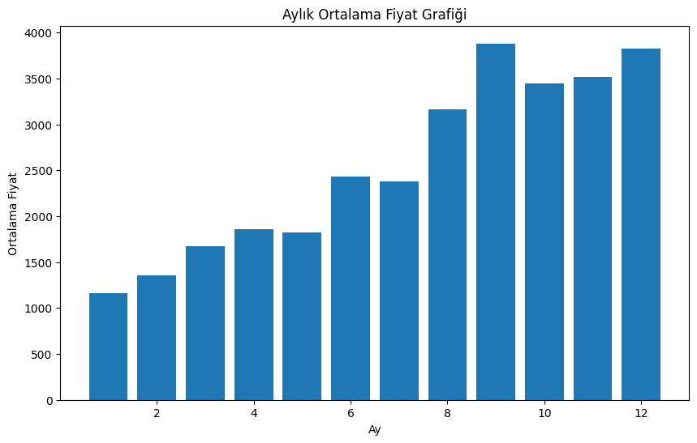

```python
# 4. Aylık Ortalama Fiyat Grafiği
df['month'] = df['date'].dt.month
monthly_average_prices = df.groupby('month')['price'].mean()

plt.figure(figsize=(10, 6))
plt.bar(monthly_average_prices.index, monthly_average_prices.values)
plt.xlabel('Ay')
plt.ylabel('Ortalama Fiyat')
plt.title('Aylık Ortalama Fiyat Grafiği')
plt.show()
```

2022 yılında aylık bazda zamana göre fiyatların ortalamasında artış olduğunu söyleyebiliriz.

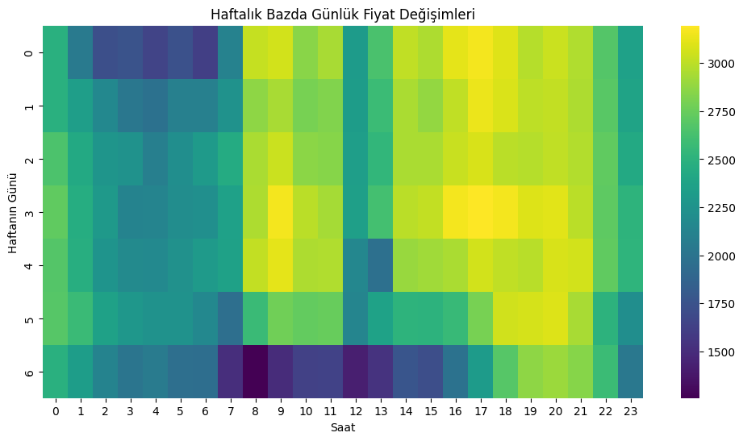

```python
# 5. Haftalık ve Günlük Fiyat Değişimleri
df['weekday'] = df['date'].dt.weekday
df['hour'] = df['date'].dt.hour
weekly_avg_prices = df.groupby(['weekday', 'hour'])['price'].mean().unstack()

plt.figure(figsize=(12, 6))
sns.heatmap(weekly_avg_prices, cmap='viridis', annot=False, fmt='.2f')
plt.xlabel('Saat')
plt.ylabel('Haftanın Günü')
plt.title('Haftalık Bazda Günlük Fiyat Değişimleri')
plt.show()
```

Yukarıdaki sıcaklık grafiğine göre haftanın günleri bazında gün doğumundan sonra 8-9-10-11 saatlerinde bir fiyat artışı gözlenmektedir. 12 ve 13te düşüş ve sonra gece saatlerine kadar bir fiyat artışı gözlemlenmiştir

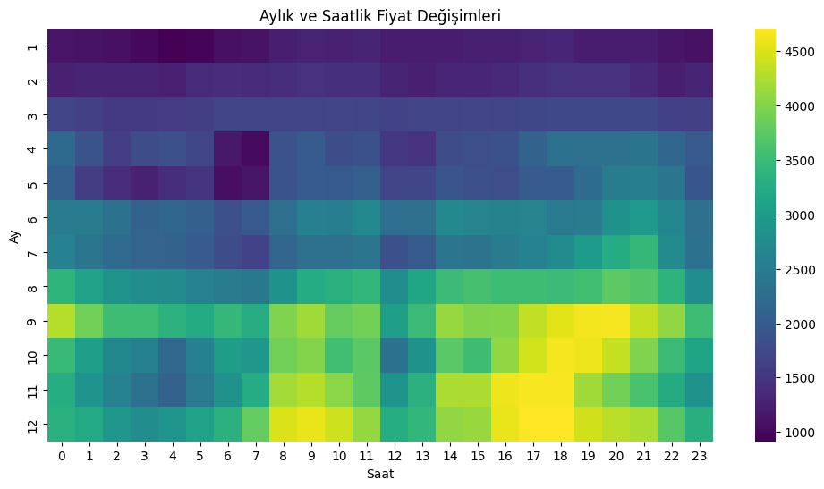

```python
# 6. Isı Haritası (örnek olarak aylık ve saatlik veriler için)
monthly_hourly_avg_prices = df.groupby(['month', 'hour'])['price'].mean().unstack()

plt.figure(figsize=(12, 6))
sns.heatmap(monthly_hourly_avg_prices, cmap='viridis', annot=False, fmt='.2f')
plt.xlabel('Saat')
plt.ylabel('Ay')
plt.title('Aylık ve Saatlik Fiyat Değişimleri')
plt.show()
```

Fiyatların en yüksek değerine ulaştığı zamanı 9,10,11,12. aylar olarak söyleyebiliriz.

# 2. Sezgisel Kuralın Performansının Değerlendirilmesi

## 2.1. Sezgisel Kural Uygulanması (T-3)

T-3 sezgisel kuralı, elektrik piyasalarında kullanılan bir kuraldır ve dengesizlik tahminlerinde kullanılır. Elektrik piyasaları, arz ve talep dengesini sürekli olarak sağlamak zorundadır, çünkü elektrik enerjisi anında tüketilmesi gereken ve kolayca depolanamayan bir üründür. Dengesizlik, tüketim ve üretim arasındaki farkın olması durumudur ve bu farklar, enerji sistemini istikrarsız hale getirebilir.

T-3 sezgisel kuralı, şu anki saat (T) ile 3 saat önceki saat (T-3) arasındaki dengesizlik yönünün (arz fazlalığı veya talep fazlalığı) benzer olduğunu varsayar. Bu kural, özellikle gün içi elektrik piyasasında, dengesizlik yönetimi ve dengesizlik fiyatlarının tahmin edilmesinde kullanılır. Mantığı, geçmiş saatlerdeki dengesizlik yönünün, mevcut saatteki dengesizlik yönü üzerinde belirleyici bir etkisi olduğunu düşünmektir.

Aşağıda, belirtilen kuralın performansı ölçülmüş ve yorumlanmıştır.

```python
df["predicted_smp_direction"] = df["smpDirection"].shift(3)
df = df.dropna() # Lag alındıktan sonra ilk üç veri hesaplanamayacağı için ve aynı zamanda metrik sonucunu etkileyeceği için düşürülmüştür.
```

## 2.2. Performans Metriklerinin Hesaplanması

Sezgisel kuralın performansının hesaplanması için doğruluk (accuracy) metriği kullanılmıştır.

```python
accuracy = (df["smpDirection"] == df["predicted_smp_direction"]).mean()
print(f"Sezgisel kuralın performansı: {accuracy:.2%}")
```

```
Sezgisel kuralın performansı: 79.76%
```

### 2.3. Saatlik ve Aylık Performans Analizi

Saatlik ve aylık performansı analiz etmek için, saat ve ay sütunları oluşturulmuş ve doğrulukları hesaplanmıştır.

```python
df["hour"] = df["date"].dt.hour
df["month"] = df["date"].dt.month

hourly_accuracy = df.groupby("hour").apply(lambda x: (x["smpDirection"] == x["predicted_smp_direction"]).mean())
monthly_hourly_accuracy = df.groupby(["month", "hour"]).apply(lambda x: (x["smpDirection"] == x["predicted_smp_direction"]).mean())

print("Saatlik performans:")
print(hourly_accuracy)

print("\nAylık bazda saatlik performans:")
print(monthly_hourly_accuracy.unstack())
```

```
Saatlik performans:
hour
0     0.788462
1     0.760989
2     0.752747
3     0.767123
4     0.813699
5     0.830137
6     0.742466
7     0.739726
8     0.761644
9     0.736986
10    0.794521
11    0.832877
12    0.772603
```

[output cut: 60 more lines]

- Sezgisel kuralın genel performansı: %79.76
- Özellikle saatlik ve aylık performans analizlerinde, sezgisel kuralın bazı saatlerde ve aylarda daha iyi performans gösterdiği görülüyor. Bu, kuralın belirli durumlar için daha uygun olduğunu düşündürebilir.

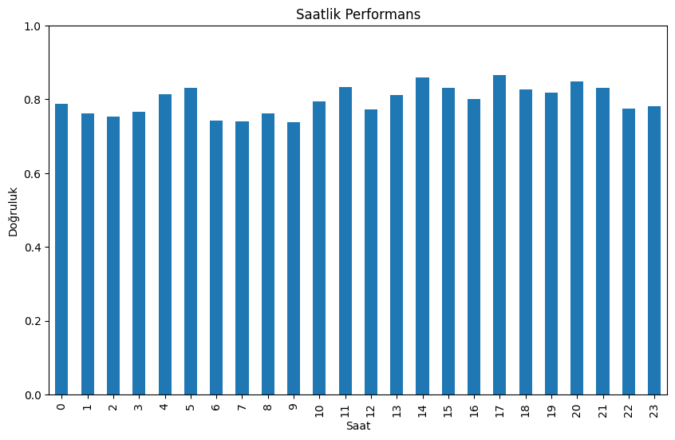

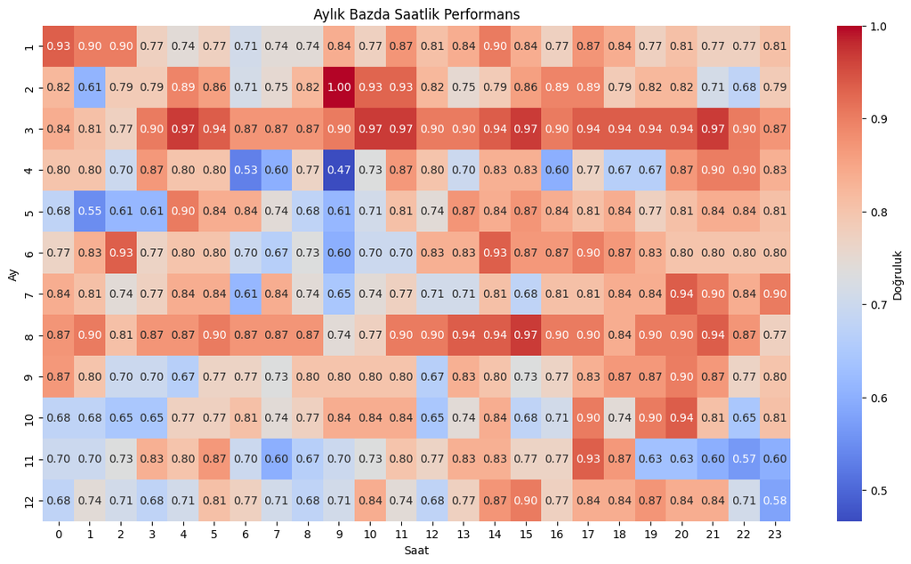

```python
# Saatlik performans
plt.figure(figsize=(10, 6))
hourly_accuracy.plot(kind="bar")
plt.title("Saatlik Performans")
plt.xlabel("Saat")
plt.ylabel("Doğruluk")
plt.ylim(0, 1)
plt.show()

# Aylık bazda saatlik performans
plt.figure(figsize=(15, 8))
sns.heatmap(monthly_hourly_accuracy.unstack(), annot=True, fmt=".2f", cmap="coolwarm", cbar_kws={"label": "Doğruluk"})
plt.title("Aylık Bazda Saatlik Performans")
plt.xlabel("Saat")
plt.ylabel("Ay")
plt.show()
```

##### Saatlik Performans

Sezgisel kuralın saatlik performansı grafiği, kuralın bazı saatlerde daha iyi performans gösterdiğini göstermektedir. Özellikle, saat 17'de en yüksek doğruluk oranına (%86.6) ulaşılırken, saat 9'da en düşük doğruluk oranıyla (%73.7) karşılaşılmaktadır. Bu, enerji talebinin ve arzının belirli saatlerde daha öngörülebilir olduğunu ve kuralın bu saatlerde daha başarılı olduğunu gösteriyor olabilir

# 3. İleri Dönemler İçin Dengesizlik Yönü Tahmini

## 3.1. EPİAŞ'tan "DGP Talimat REST Servisi" Verilerini Çekme

EPİAŞ'tan "DGP Talimat REST SERVİSİ" verilerini çekmek için, gerekli parametreler ve request URL'si belirlenmiş.

#### Parametreler

```python
base_url = "https://seffaflik.epias.com.tr/transparency/service/market/bpm-order-summary"
start_date = "2018-01-01"
end_date = "2022-12-31"

params = {
    "startDate": start_date,
    "endDate": end_date
}

dgp_response = requests.get(base_url, params=params)
dgp_data = dgp_response.json()
```

## 3.2. Veriyi Pandas DataFrame'e Dönüştürme

Çeşitli ön işlemelerin yapılması için veri pandas DataFrame'e dönüştürülmüştür

```python
# 'bpmOrderSummaryList' anahtarını kullanarak ilgili bilgilerin elde edilmesi
dgp_list = dgp_data['body']["bpmOrderSummaryList"]

# Tüm saatler için ilgili verileri içeren bir DataFrame oluşturulması
hour_data = []

for hour_info in dgp_list:
    hour_info["tarih"] = pd.to_datetime(hour_info["date"], format="%Y-%m-%dT%H:%M:%S.%f%z")
    hour_data.append(hour_info)

# Tüm saatlerin verilerini içeren tek bir DataFrame oluşturulması
dgp_df = pd.DataFrame(hour_data)
```

## 3.3. Özellik Çıkarımı

### 3.3.1. Covid Flag

TimeSeries problemlerinde Covid-19 dönemine Flag atamak doğru bir yaklaşım olabilir.

```python
dgp_df["covid_flag"] = np.where((dgp_df["date"] >= "2020-03-11") & (dgp_df["date"] <= "2022-05-31"), 1, 0)
```

### 3.3.2. Tarihsel Özellik Çıkarımı

```python
dgp_df['Year'] = dgp_df['tarih'].dt.year
dgp_df['Month'] = dgp_df['tarih'].dt.strftime('%B')
dgp_df['Day'] = dgp_df['tarih'].dt.day
dgp_df['Day of Week'] = dgp_df['tarih'].dt.strftime('%A')
dgp_df['Day of Year'] = dgp_df['tarih'].dt.day_of_year
dgp_df['Series'] = np.arange(0,len(dgp_df))+1
dgp_df['decmonth'] = dgp_df['tarih'].dt.month
dgp_df["hour"] = dgp_df["tarih"].dt.hour
# Gün başlangıçlarının belirlenmesi
dgp_df['day_start'] = dgp_df['hour'] == 0
```

### 3.3.3. net Değişkeninden Özellik Çıkarımları

```python
dgp_df.columns
```

```
Index(['date', 'net', 'upRegulationZeroCoded', 'upRegulationOneCoded',
       'upRegulationTwoCoded', 'downRegulationZeroCoded',
       'downRegulationOneCoded', 'downRegulationTwoCoded',
       'upRegulationDelivered', 'downRegulationDelivered', 'direction',
       'nextHour', 'tarih', 'covid_flag', 'Year', 'Month', 'Day',
       'Day of Week', 'Day of Year', 'Series', 'decmonth', 'hour',
       'day_start'],
      dtype='object')
```

```python
# Günlerin başlangıçlarının alınması
day_starts = dgp_df[dgp_df['day_start']].index.tolist()

variables = [
    "upRegulationZeroCoded",
    "upRegulationOneCoded",
    "upRegulationTwoCoded",
    "downRegulationZeroCoded",
    "downRegulationOneCoded",
    "downRegulationTwoCoded",
    "upRegulationDelivered",
    "downRegulationDelivered",
]

for var in variables:
    dgp_df[f"{var}_cumulative_avg"] = 0.0

    for i in range(len(day_starts)):
        start = day_starts[i]
        if i < len(day_starts) - 1:
            end = day_starts[i + 1]
        else:
            end = len(dgp_df)
        cum_sum = 0
        count = 0
        for j in range(start, end):
            cum_sum += dgp_df.loc[j, var]
            count += 1
            dgp_df.loc[j, f"{var}_cumulative_avg"] = cum_sum / count

    for lag in range(1, 24):
        dgp_df[f"{var}_lag{lag}"] = dgp_df[var].shift(lag)
```

[output not shown]

[output cut: 168 more lines]

## 3.4. Dış Verilerin Eklenmesi

### 3.4.1. Özel Günler

Özel günler, zaamn serisi analizinde oldukça faydalıdır. Belirli bir tarihsel veri çerçevesinde özel günlerin varlığı, bu özel günlerin satış, trafiğin yoğunluğu, vb. gibi farklı verilerin analizinde kullanılabilir.

```python
df = dgp_df.copy()
dfs = pd.read_html('http://www.bulanik.gov.tr/ulkemizde-kutlanan-onemli-gun-ve-haftalar')
i_days = pd.concat(dfs)
conv_months = {'Ocak':1,'Şubat':2,'Mart':3,'Nisan':4,'Mayıs':5,'Haziran':6,'Temmuz':7,'Ağustos':8,'Eylül':9,'Ekim':10,'Kasım':11,'Aralık':12}
i_days = i_days[i_days[0].str.contains('Günü')]
i_days=i_days[~i_days[1].str.contains('ilk')]
i_days = i_days[~i_days[1].str.contains('-')]
new_months = i_days[1].str.split(' ',expand=True)[1].replace(conv_months)

i_days['days'] = i_days[1].str.split(' ',expand=True)[0]
i_days['months'] = new_months

i_days['days']=i_days['days'].astype('int64')

df['Year'] = df['tarih'].dt.year
df['Month'] = df['tarih'].dt.strftime('%B')
df['Day'] = df['tarih'].dt.day
df['Day of Week'] = df['tarih'].dt.strftime('%A')
df['Day of Year'] = df['tarih'].dt.day_of_year
df['Series'] = np.arange(0,len(df))+1
df['decmonth'] = df['tarih'].dt.month
```

```python
new_df = pd.merge(df, i_days,  how='left', left_on=['decmonth','Day'], right_on = ['months','days'])
new_df = new_df.drop([1,'months'],axis=1).rename(columns={0:'Important Days'})
new_df['Important Days'] = new_df['Important Days'].fillna('-')
```

```python
new_df.to_csv('extended_data2.csv',index=False)
```

### 3.4.2. Hava Durumu ve Yağış Verisi

Bu aşamayı baştan çalıştırmak yerine, weather_df'in okutularak eklendiği kısma geçebilirsiniz. Hava durumu verisinin çekildiği API'nın aylık request sınırı olduğu için o kısım çalışmayabilir.

Enerji talebi, hava durumu gibi çeşitli faktörlere bağlı olarak değişkenlik gösterir. Örneğin, sıcaklık, nem, rüzgar hızı ve güneş ışınımı gibi parametreler, enerji talebini etkileyen ısıtma, soğutma ve aydınlatma ihtiyacını belirler. Aynı şekilde, enerji arzı da hava durumuna bağlı olarak değişebilir. Özellikle yenilenebilir enerji kaynaklarından (RES) elektrik üretimi, rüzgar ve güneş gibi hava koşullarına bağlıdır. Bu nedenle, RES’in enerji karışımındaki payı arttıkça, enerji arzının öngörülebilirliği azalır ve şebeke dengesizlikleri daha büyük olur.

Bu bağlamda, hava durumu verilerinin enerji sektöründe dengesizlik yönü tahmini için gerekli olduğu açıktır. Hava durumu verileri, enerji talebi ve arzı modellerinin girdisi olarak kullanılabilir.

#### 3.4.3.1. Türkiyedeki En Büyük 10 Enerji Üretim Merkezlerinin Toplanması (Güneş,Rüzgar,Hidroelektrik)

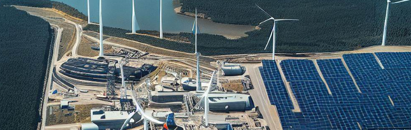

```python
def scrape_table_from_url(url, type):
    page = requests.get(url)
    soup = BeautifulSoup(page.content, 'html.parser')
    table_html = str(soup.find_all('table'))
    if type == 'gunes':
        df = pd.read_html(table_html)[0]
    elif type == 'ruzgar':
        df = pd.read_html(table_html)[0]
    elif type == 'hidroelektrik':
        df = pd.read_html(table_html)[0]
    return df


url = 'https://www.enerjiatlasi.com/en-buyuk/gunes'
df_gunes = scrape_table_from_url(url, 'gunes')

url = 'https://www.enerjiatlasi.com/en-buyuk/ruzgar'
df_ruzgar = scrape_table_from_url(url, 'ruzgar')

url = 'https://www.enerjiatlasi.com/en-buyuk/hidroelektrik'
df_hidroelektrik = scrape_table_from_url(url, 'hidroelektrik')

df = pd.concat([df_ruzgar, df_hidroelektrik], ignore_index=True)
```

```python
illist = df['İl'].unique().tolist()
```

```python
weather_df = pd.DataFrame()
enddate = datetime.today()
startdate = 0
for j in range(1,65):
    citydf1 = pd.DataFrame()
    startdate = enddate - dt.timedelta(days=30)
    startst = startdate.strftime('%Y-%m-%d')
    endst = enddate.strftime('%Y-%m-%d')
    for city in illist:
        citydf = pd.DataFrame()
        url = f'https://api.worldweatheronline.com/premium/v1/past-weather.ashx?date={startst}&enddate={endst}&key=7742a8f8a86a4d4ba2d165007230504&q={city},turkey&format=json'
        r = requests.get(url)
        jres = json.loads(r.text)


        try:
            for i in range(len(jres['data']['weather'])):

                my_dict = {
                            f'{city}_date' : jres['data']['weather'][i]['date'] ,
                            f'{city}_avgtempC' :  jres['data']['weather'][i]['avgtempC'],
                            f'{city}_sunrise' :  jres['data']['weather'][i]['astronomy'][0]['sunrise'],
                            f'{city}_sunset' :  jres['data']['weather'][i]['astronomy'][0]['sunset'],
                            f'{city}_windspeedKmph':  jres['data']['weather'][i]['hourly'][5]['windspeedKmph'],
                            f'{city}_uvIndex' : jres['data']['weather'][i]['uvIndex'],
                            f'{city}_precipitation':  float(jres['data']['weather'][i]['totalSnow_cm']) + (float(jres['data']['weather'][i]['hourly'][5]['precipMM'])*10)


                            }
                citydf = citydf.append(pd.DataFrame(my_dict,index=[i]))
        except Exception as e:
            print(e)
            break

        citydf1 = pd.concat([citydf1,citydf],axis=1)
    weather_df = weather_df.append(citydf1)

    enddate = enddate - pd.DateOffset(months=1)

weather_df = weather_df.drop_duplicates()
# _date ile biten sütunları bul
date_columns = [col for col in weather_df.columns if col.endswith('_date') and col != 'İstanbul_date']

# istenmeyen sütunları düşür ve istanbul_date'i yeniden adlandır, ardından index olarak ata
weather_df = weather_df.drop(date_columns, axis=1).rename(columns={'İstanbul_date': 'date'}).set_index('date')
weather_df.index = pd.to_datetime(weather_df.index)
weather_df = weather_df.sort_index()
```

```python
#weather_df.to_csv('weather2.csv')
```

```python
weather_df = pd.read_csv("weather2.csv")
```

```python
import pandas as pd
import pytz

# weather_df veri çerçevesine yeni bir index oluştur. bu index EPIAS'tan gelen tarih değişkeniyle aynı türe sahip olmalı
start_date = pd.Timestamp('2017-12-07', tz=pytz.FixedOffset(180))
weather_df.index = pd.date_range(start=start_date, periods=len(weather_df), freq='D')
weather_df = weather_df.drop('date',axis=1)
```

```python
#birden fazla sunset ve sunrise verilerini düşür çünkü dakikalar diğer bölgelerde çok fazla değişmiyor. Türkiye'nin ortası diyebileceğim Sivas merkez olarak baz al.
cols_to_drop = [col for col in weather_df.columns if col.endswith('_sunset') or col.endswith('_sunrise')]
cols_to_drop = list(set(cols_to_drop) - {'Sivas_sunset', 'Sivas_sunrise'})
weather_df = weather_df.drop(cols_to_drop, axis=1)
weather_df = weather_df.rename(columns={'Sivas_sunset': 'sunset', 'Sivas_sunrise': 'sunrise'})
```

```python
# sunrise ve sunset değişkenlerini modelin anlayacağı bir standarda dönüştür
def time_to_minutes(time_str):
    hours, minutes = map(int, time_str.split(':'))
    return hours * 60 + minutes

weather_df['sunrise_minutes'] = weather_df['sunrise'].str.extract(r'(\d{1,2}:\d{2})').apply(lambda x: time_to_minutes(x[0]), axis=1)
weather_df['sunset_minutes'] = weather_df['sunset'].str.extract(r'(\d{1,2}:\d{2})').apply(lambda x: time_to_minutes(x[0]), axis=1)
```

```python
#birleştirme işlemlerini gerçekleştir
weather_df = weather_df.drop(['sunrise','sunset'],axis=1)
new_df = pd.read_csv('extended_data2.csv')
new_df = new_df.drop_duplicates(subset='date')
new_df['date'] = pd.to_datetime(new_df['date'])


merged_df = pd.merge_asof(new_df, weather_df, left_on='date', right_index=True,allow_exact_matches=False)
merged_df = merged_df.drop('days',axis=1)
merged_df = merged_df.dropna()
```

```python
merged_df.to_csv('merged_df3.csv',index=False)
```

```python
merged_df = pd.read_csv('merged_df3.csv')
```

# 4. Modelleme

##### Bağımlı Değişkenin Oluşturulması

Mevcut zamandan 3 saat sonraki dengesizlik yönü tahmin edileceği için, bütün veriyi 3 periyot laglamak için bağımlı değişkeni -3 saat ileri atıyoruz.

```python
#Geçmiş saatlerdeki verilere dayalı özellikler eklemek için 'shift' fonksiyonu kullanarak bağımlı değişkeni tanımla

merged_df["target_direction"] = merged_df["direction"].shift(-3)
```

```python
merged_df = merged_df.dropna()
```

## 4.1. Özellik Seçiminin Yapılması

(Bu kısım da uzun sürdüğü için, pickle ile daha önceden kaydedilmiş boruta modelini import edebilirsiniz)

Boruta, Rastgele Orman Sınıflandırıcı algoritması temelinde çalışan bir özellik seçimi yöntemidir. Boruta algoritmasının arkasındaki fikir hem ilginç hem de basittir: orijinal veri kümesindeki tüm özelliklerin rastgele kopyalarını oluştururuz (gölge özellikler olarak adlandırılır) ve bu genişletilmiş veri kümesine dayalı olarak sınıflandırıcılar eğitiriz. Bir özelliğin önemini anlamak için, onu oluşturduğumuz tüm gölge özelliklerle karşılaştırırız. Sadece bu sentetik özelliklerden istatistiksel olarak daha önemli olan özellikleri tutarız, çünkü bunlar model performansına daha fazla katkıda bulunurlar.

Boruta algoritması şu adımları izler:

- Orijinal veri kümesindeki tüm özellikleri kopyalar ve bunları orijinal özelliklerle birleştirir.
- Gölge özelliklere rastgele değerler atar ve bunları orijinal özelliklerden ayırt etmek için adlarını değiştirir.
- Rastgele Orman Sınıflandırıcı algoritmasını genişletilmiş veri kümesine uygular ve her bir özelliğin önemini hesaplar.
- Gölge özelliklerin maksimum önemini alır ve bunu bir eşik değeri olarak kullanır.
- Orijinal özelliklerden eşik değerinden daha az öneme sahip olanları reddeder, eşit veya daha fazla öneme sahip olanları onaylar veya geçici olarak tutar.
- Reddedilen veya onaylanan tüm özellikleri kaldırır ve geri kalan gölge özelliklerin değerlerini yeniden karıştırır.
- Bir sonraki iterasyonda yukarıdaki adımları tekrarlar.
- Tüm orijinal özellikler reddedilene veya onaylanana kadar veya belirlenen maksimum iterasyon sayısına ulaşılana kadar devam eder.

```python
from boruta import BorutaPy
from sklearn.preprocessing import LabelEncoder
from sklearn.ensemble import RandomForestClassifier


var = 'target_direction'

X = merged_df.drop([var,'date','nextHour','tarih'], axis=1)
y = merged_df[var]

rf = RandomForestClassifier(n_jobs=-1, class_weight='balanced', n_estimators=200, max_depth=7, min_samples_split=5)
boruta_feature_selector = BorutaPy(rf, n_estimators='auto', verbose=2, random_state=1, max_iter=100, perc=100)

categorical_columns = X.select_dtypes('object').columns.tolist()  # Kategorik sütun adlarını liste halinde sağlayın

label_encoder = LabelEncoder()

for column in categorical_columns:
    X[column] = label_encoder.fit_transform(X[column])

# Boruta ile özellik seçimini gerçekleştirin
boruta_feature_selector.fit(np.array(X), np.array(y))

import pickle

# Boruta seçicisini 'importances' klasörüne kaydedin
with open(f'{var}_boruta_selector2.pkl', 'wb') as f:
    pickle.dump(boruta_feature_selector, f)

print(f"{var} için Boruta seçici kaydedildi.")
```

```
Iteration: 	1 / 100
Confirmed: 	0
Tentative: 	287
Rejected: 	0
Iteration: 	2 / 100
Confirmed: 	0
Tentative: 	287
Rejected: 	0
Iteration: 	3 / 100
Confirmed: 	0
Tentative: 	287
Rejected: 	0
Iteration: 	4 / 100
Confirmed: 	0
Tentative: 	287
Rejected: 	0
Iteration: 	5 / 100
Confirmed: 	0
Tentative: 	287
Rejected: 	0
Iteration: 	6 / 100
Confirmed: 	0
Tentative: 	287
Rejected: 	0
Iteration: 	7 / 100
Confirmed: 	0
Tentative: 	287
Rejected: 	0
Iteration: 	8 / 100
Confirmed: 	110
Tentative: 	34
Rejected: 	143
Iteration: 	9 / 100
Confirmed: 	110
Tentative: 	34
Rejected: 	143
Iteration: 	10 / 100
Confirmed: 	110
Tentative: 	34
Rejected: 	143
```

[output cut: 350 more lines]

```
Tentative: 	14
Rejected: 	161
Iteration: 	99 / 100
Confirmed: 	112
Tentative: 	14
Rejected: 	161


BorutaPy finished running.

Iteration: 	100 / 100
Confirmed: 	112
Tentative: 	5
Rejected: 	161
target_direction için Boruta seçici kaydedildi.
```

```python
import pickle

var = "target_direction"

with open(f'target_direction_boruta_selector2.pkl', 'rb') as f:
        boruta_selector = pickle.load(f)

# Özellik sıralamalarını ve isimlerini elde edin
feature_ranks = boruta_selector.ranking_
feature_names = merged_df.drop([var,'date','nextHour','tarih'], axis=1).columns

# Özellikleri sıralayın ve en
sorted_features = sorted(zip(feature_names, feature_ranks), key=lambda x: x[1])
top_features = [feature[0] for feature in sorted_features[:boruta_selector.n_features_]]
```

## 4.2. Modelin Eğitimi ve Tahminlerin Yapılması

### 4.2.1. Modele Girecek Verilerin ve Değişkenlerin Belirlenmesi

```python
# Modele Boruta'nın çıktı verdiği değişkenlerin verilmesi.
feature_ranks = boruta_selector.ranking_
feature_names = merged_df.drop([var,'date','nextHour','tarih'], axis=1).columns

sorted_features = sorted(zip(feature_names, feature_ranks), key=lambda x: x[1])
top_features = [feature[0] for feature in sorted_features[:boruta_selector.n_features_]]

list1 = merged_df.columns.tolist()
list2 = top_features

ignorelist = [item for item in list1 if item not in list2]
ignorelist.remove('target_direction')
ignorelist = ignorelist +  ['nextHour','tarih']
```

#### 4.2.2. PyCaret

PyCaret, Python’da makine öğrenimi iş akışlarını otomatikleştiren açık kaynaklı, düşük kodlu bir makine öğrenimi kütüphanesidir. PyCaret ile makine öğrenimi modellerini eğitmek, değerlendirmek, karşılaştırmak, optimize etmek ve dağıtmak için yüzlerce satır kod yerine sadece birkaç satır kod yazılabilir.

PyCaret’in avantajları şunlardır:

- Hızlı ve kolay kurulum. PyCaret pip veya conda ile yüklenebilir veya Docker ile çalıştırılabilir.
- Modüler ve tutarlı tasarım. PyCaret, belirli makine öğrenimi görevlerini kapsayan modüllerden oluşur. Her modüldeki fonksiyonlar birbiriyle uyumludur ve diğer modüllerle de çalışabilir.
- Veri ön işleme ve özellik mühendisliği desteği. PyCaret, verileri ölçeklendirmek, dönüştürmek, eksik değerleri doldurmak, kategorik değişkenleri kodlamak, aykırı değerleri tespit etmek ve gidermek gibi birçok veri ön işleme işlevi sunar. Ayrıca, verilerden yeni özellikler türetmek için PCA, RFE ve diğer yöntemleri de kullanabilir.
- Çoklu model eğitimi ve karşılaştırma. PyCaret, bir veri seti üzerinde birden fazla modelin otomatik olarak eğitilmesine ve performanslarının çeşitli metriklerle karşılaştırılmasına olanak tanır. Bu şekilde en uygun modeli seçilebilir.
- Model optimizasyonu ve seçimi. PyCaret, model hiperparametrelerini optimize etmek için ızgara araması (GridSearch) veya rastgele arama (RandomSearch) gibi yöntemleri kullanabilir. Ayrıca, model seçimi için çapraz doğrulama veya katmanlı doğrulama gibi teknikleri de uygulayabilirsiniz1.
- Model açıklaması ve yorumlanması. PyCaret, eğitilmiş modellerin nasıl çalıştığını anlamak için çeşitli araçlar sunar. Örneğin, ROC eğrisi, hassasiyet-duyarlılık eğrisi, karışıklık matrisi gibi performans göstergelerini gösterebilir. Ayrıca, SHAP gibi kütüphaneleri kullanarak modelin tahminlerini açıklayabilir veya etkileşimli olarak görselleştirilebilir.
- Model dağıtımı ve izlenmesi. PyCaret, eğitilmiş modellerin REST API olarak dağıtılmasına veya basit bir web uygulaması oluşturulmasına olanak tanır. Ayrıca, model AWS veya Azure gibi bulut platformlara dağıtılabilir veya MLflow gibi araçlarla izlenebilir.

```python
from pycaret.classification import *
```

```python
valid_data = merged_df[(merged_df['date']<'2022') & (merged_df['date']>'2021')]
test_data = merged_df[(merged_df['date']>'2022')]
train_data = merged_df[(merged_df['date']<'2021') & (merged_df['date']>'2019')]
```

```python
clf = setup(data=train_data,
            test_data=valid_data,
            data_split_shuffle=False,
            fold=10,
            data_split_stratify= True,
            fold_strategy="timeseries",
            target="target_direction",
            ignore_features=ignorelist,
            categorical_features=['Year'],
            session_id=1901)
```

|  | Description | Value |
| --- | --- | --- |
| 0 | Session id | 1901 |
| 1 | Target | target_direction |
| 2 | Target type | Multiclass |
| 3 | Target mapping | ENERGY_DEFICIT: 0, ENERGY_SURPLUS: 1, IN_BALANCE: 2 |
| 4 | Original data shape | (26304, 291) |
| 5 | Transformed data shape | (26304, 113) |
| 6 | Transformed train set shape | (17544, 113) |
| 7 | Transformed test set shape | (8760, 113) |
| 8 | Ignore features | 180 |
| 9 | Ordinal features | 1 |
| 10 | Numeric features | 108 |
| 11 | Categorical features | 1 |
| 12 | Preprocess | True |
| 13 | Imputation type | simple |
| 14 | Numeric imputation | mean |
| 15 | Categorical imputation | mode |
| 16 | Maximum one-hot encoding | 25 |
| 17 | Encoding method | None |
| 18 | Fold Generator | TimeSeriesSplit |
| 19 | Fold Number | 10 |
| 20 | CPU Jobs | -1 |
| 21 | Use GPU | False |
| 22 | Log Experiment | False |
| 23 | Experiment Name | clf-default-name |
| 24 | USI | c1b4 |

- "data" parametresi, eğitim veri kümesini belirtir.
- "test_data" parametresi, doğrulama veri kümesini belirtir.
- "data_split_shuffle" parametresi, verilerin karıştırılıp karıştırılmayacağını belirtir.
- "data_split_stratify" parametresi, verilerin ayrıştırılırken oranlarına dikkat edilip edilmeyeceğini belirtir.
- "fold_strategy" parametresi, çapraz doğrulama yöntemini belirtir. Bu örnekte, "timeseries" olarak belirtilmiştir, bu da zaman serisi tabanlı bir çapraz doğrulama yapılacağı anlamına gelir.
- "target" parametresi, hedef değişkeni belirtir.
- "ignore_features" parametresi, model eğitimi için kullanılmayacak özellikleri belirtir.
- "categorical_features" parametresi, kategorik özellikleri belirtir.

```python
#best_model = compare_models()
```

PyCaret'ın compare_models fonksiyonu, bu kütüphanenin barındırdığı bütün alogirtmaları eğitir, sonuçlarını test eder ve modelleri başarılarına göre sıralar. (Bu kısım zamandan tasarruf etmek için tekrar tekrar çalıştırılmamak commente alınmıştır. Bu adımda en başarılı model LightGBM çıkmıştır)

```python
#lightgbm modelinin eğitilmesi
model = create_model('lightgbm')
```

| Initiated | . . . . . . . . . . . . . . . . . . | 01:24:42 |
| --- | --- | --- |
| Status | . . . . . . . . . . . . . . . . . . | Loading Dependencies |
| Estimator | . . . . . . . . . . . . . . . . . . | Compiling Library |

| Fold | Accuracy | AUC | Recall | Prec. | F1 | Kappa | MCC |
| --- | --- | --- | --- | --- | --- | --- | --- |
| 0 | 0.5797 | 0.6908 | 0.5797 | 0.6009 | 0.5553 | 0.2030 | 0.2285 |
| 1 | 0.7371 | 0.8208 | 0.7371 | 0.7248 | 0.7302 | 0.4844 | 0.4857 |
| 2 | 0.7284 | 0.8219 | 0.7284 | 0.7066 | 0.7103 | 0.4749 | 0.4778 |
| 3 | 0.6537 | 0.7535 | 0.6537 | 0.6420 | 0.6383 | 0.3495 | 0.3609 |
| 4 | 0.6518 | 0.7443 | 0.6518 | 0.6300 | 0.6285 | 0.3098 | 0.3164 |
| 5 | 0.6951 | 0.7919 | 0.6951 | 0.6938 | 0.6604 | 0.3605 | 0.4047 |
| 6 | 0.6951 | 0.8053 | 0.6951 | 0.6780 | 0.6757 | 0.4252 | 0.4328 |
| 7 | 0.7785 | 0.8484 | 0.7785 | 0.7628 | 0.7559 | 0.4765 | 0.4909 |
| 8 | 0.7604 | 0.8274 | 0.7604 | 0.7315 | 0.7314 | 0.3907 | 0.4054 |
| 9 | 0.6593 | 0.7860 | 0.6593 | 0.6743 | 0.6402 | 0.3580 | 0.3846 |
| Mean | 0.6939 | 0.7890 | 0.6939 | 0.6845 | 0.6726 | 0.3833 | 0.3988 |
| Std | 0.0568 | 0.0450 | 0.0568 | 0.0474 | 0.0576 | 0.0833 | 0.0781 |

```python
#modelin hiperparametre optimizasyonu yapılma aşaması
tuned_model = tune_model(model,optimize='F1',fold=10,early_stopping=True)
```

| Initiated | . . . . . . . . . . . . . . . . . . | 01:40:38 |
| --- | --- | --- |
| Status | . . . . . . . . . . . . . . . . . . | Loading Dependencies |
| Estimator | . . . . . . . . . . . . . . . . . . | Compiling Library |

| Fold | Accuracy | AUC | Recall | Prec. | F1 | Kappa | MCC |
| --- | --- | --- | --- | --- | --- | --- | --- |
| 0 | 0.7051 | 0.7732 | 0.7051 | 0.6847 | 0.6941 | 0.4223 | 0.4238 |
| 1 | 0.7641 | 0.8442 | 0.7641 | 0.7491 | 0.7563 | 0.5348 | 0.5356 |
| 2 | 0.7472 | 0.8265 | 0.7472 | 0.7051 | 0.7255 | 0.5043 | 0.5075 |
| 3 | 0.6844 | 0.7667 | 0.6844 | 0.6418 | 0.6624 | 0.3736 | 0.3765 |
| 4 | 0.6832 | 0.7845 | 0.6832 | 0.6400 | 0.6594 | 0.3757 | 0.3808 |
| 5 | 0.7089 | 0.7855 | 0.7089 | 0.6862 | 0.6966 | 0.4314 | 0.4332 |
| 6 | 0.7089 | 0.8002 | 0.7089 | 0.6694 | 0.6886 | 0.4484 | 0.4510 |
| 7 | 0.7880 | 0.8704 | 0.7880 | 0.7565 | 0.7717 | 0.5242 | 0.5270 |
| 8 | 0.7516 | 0.8221 | 0.7516 | 0.7025 | 0.7256 | 0.3933 | 0.3997 |
| 9 | 0.6731 | 0.7949 | 0.6731 | 0.6391 | 0.6494 | 0.3738 | 0.3840 |
| Mean | 0.7215 | 0.8068 | 0.7215 | 0.6874 | 0.7030 | 0.4382 | 0.4419 |
| Std | 0.0368 | 0.0315 | 0.0368 | 0.0401 | 0.0391 | 0.0598 | 0.0583 |

```
Fitting 10 folds for each of 10 candidates, totalling 100 fits
```

```python
#model eğitiminin son aşaması. finalize_model fonksiyonu ile validasyon seti de modele öğretilir ve test verisini tahmin etmek içni hazır olur.
f = finalize_model(tuned_model)
```

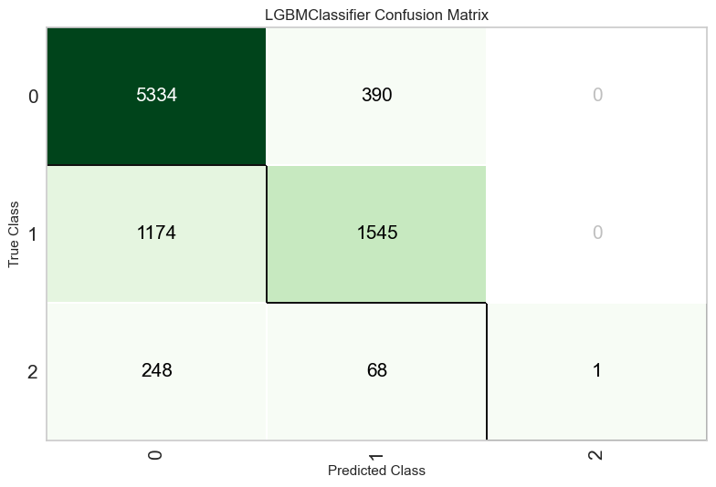

```python
plot_model(f,plot='confusion_matrix')
```

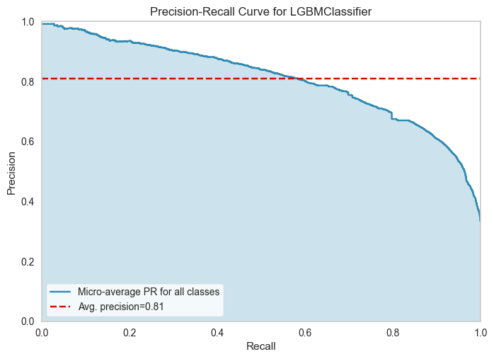

```python
plot_model(f,plot="pr")
```

Yukarıdaki PR (Precision-Recall) eğrisi, modelin doğru pozitif tahminlerinin sayısını yanıltıcı pozitif tahminlerin sayısına oranını göstererek, modelin sınıflandırma performansının ne kadar iyi olduğunu yansıtır. Yüksek bir ortalama hassasiyet değeri, modelin doğru sınıflandırma yapma becerisi olduğunu ve yanıltıcı tahminlerin oranının düşük olduğunu gösterir.

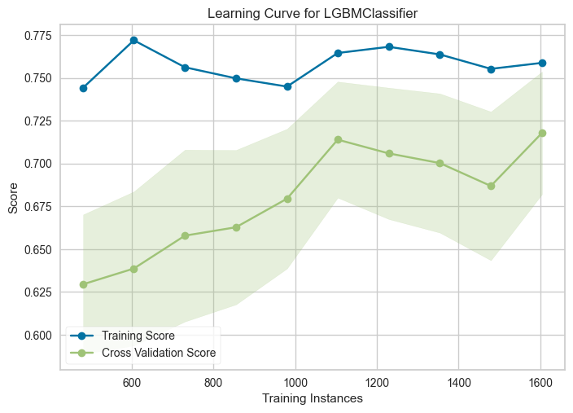

```python
plot_model(tuned_model,plot="learning",use_train_data=False)
```

Öğrenme eğrisi, başlangıçta düşük örnek sayısı nedeniyle aşırı uyma olasılığı yüksek olduğundan, örnek sayısı arttıkça modelin genelleme yapma becerisinin geliştiğini gösterir. Öğrenme eğrisi, özellikle eğitim skoru ve çapraz doğrulama skoru arasındaki açık farkın daraldığı noktaları vurgulayarak, modelin en iyi performansını hangi noktada gösterdiğini belirleyebilir. Bu durumda, örnek sayısı arttıkça, modelin eğitim ve doğrulama skorları arasındaki fark daralmış ve modelin daha iyi bir genelleme yapma yeteneği olduğu görülmüştür. Fakat buna rağmen geliştirilmeye açık olduğuda gözlemlenmektedir

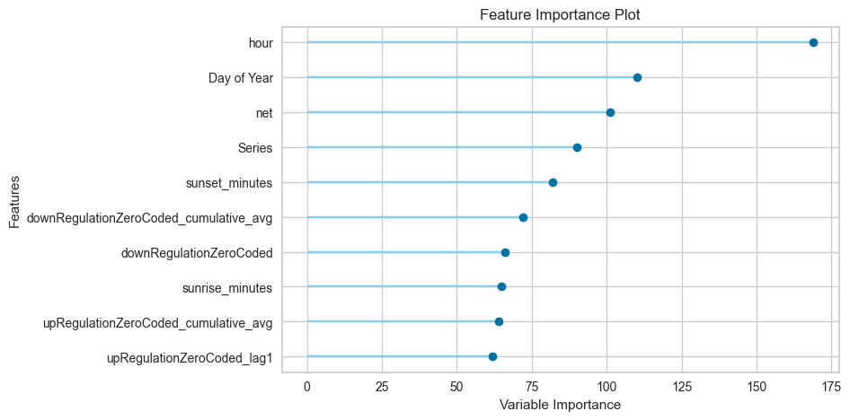

```python
plot_model(f,plot="feature",use_train_data=False)
```

Bu feature importance grafiği, bir makine öğrenimi modelinin hangi özelliklerin (features) sınıflandırmada ne kadar önemli olduğunu gösterir. Grafiğe göre, bağımlı değişkenin tahmin edilmesinde en önemli özellik saat değişkenidir. Bunu başlangıçtaki sıcaklık grafiğinde de görmüştük. Daha sonra yılın günü değişkeni gelmekte. Üçüncü en önemli değişken ise net değişkenidir. Veri setindeki trendi temsil eden Series değişkeni dördüncü en önemli değişkendir ve devamı yukarıdaki grafikteki gibidir.

### 4.2.3. Model Sonuçları ile Sezgisel Kural (T-3) Sonuçlarının Karşılaştırılması

```python
predictions = predict_model(f, data=test_data)
accuracy = accuracy_score(predictions['target_direction'], predictions['prediction_label'])
print("Accuracy: {:.2f}%".format(accuracy * 100))

px =predictions[["date","target_direction",'prediction_label','prediction_score','hour','decmonth','direction']]
```

|  | Model | Accuracy | AUC | Recall | Prec. | F1 | Kappa | MCC |
| --- | --- | --- | --- | --- | --- | --- | --- | --- |
| 0 | Light Gradient Boosting Machine | 0.8222 | 0 | 0 | 0 | 0 | 0.3558 | 0.3746 |

```
Accuracy: 82.22%
```

Dengesizlik yönü tahmini çalışmamızda, t-3 heuristik yönteminin doğruluk oranı %79,76 olarak elde edilmiştir. Bu basit tahmin yöntemi, geçmiş verilere dayanarak enerji dengesizliğinin yönünü tahmin etmeye çalışır. Bununla birlikte, geliştirdiğimiz makine öğrenimi modeli, %82,22'lik bir doğruluk oranı ile daha yüksek bir performans göstermiştir. Bu sonuç, modelimizin zaman serisi verilerine dayalı özellikler ve dış faktörler gibi daha karmaşık bilgileri kullanarak enerji dengesizlik yönünü daha doğru bir şekilde tahmin edebildiğini göstermektedir. Bu nedenle, geliştirdiğimiz modelin enerji sektörü için önemli bir değer sağlayabileceği ve t-3 heuristik yöntemine kıyasla daha doğru ve güvenilir tahminler üretebileceği söylenebilir.

##### Saatlik ve Aylık Saatlik Bazda Kıyaslama

```
Modelin saatlik performansı:
hour
0     0.756164
1     0.789041
2     0.830137
3     0.786301
4     0.769863
5     0.794521
6     0.827397
7     0.835616
8     0.868493
9     0.789041
10    0.805479
11    0.873973
12    0.868493
```

[output cut: 75 more lines]

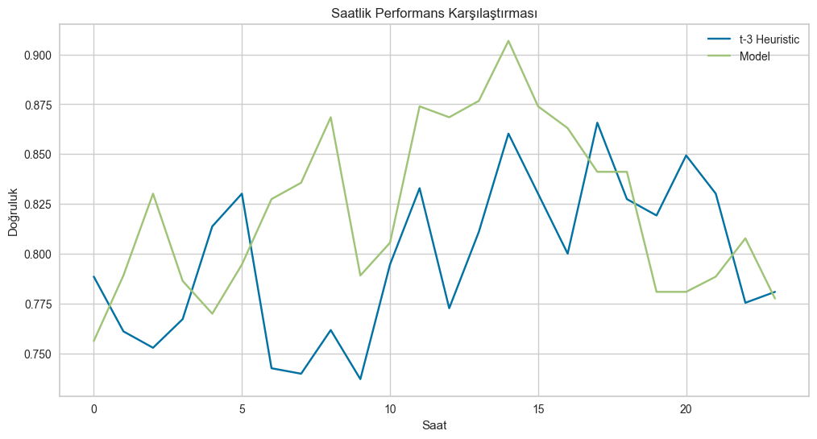

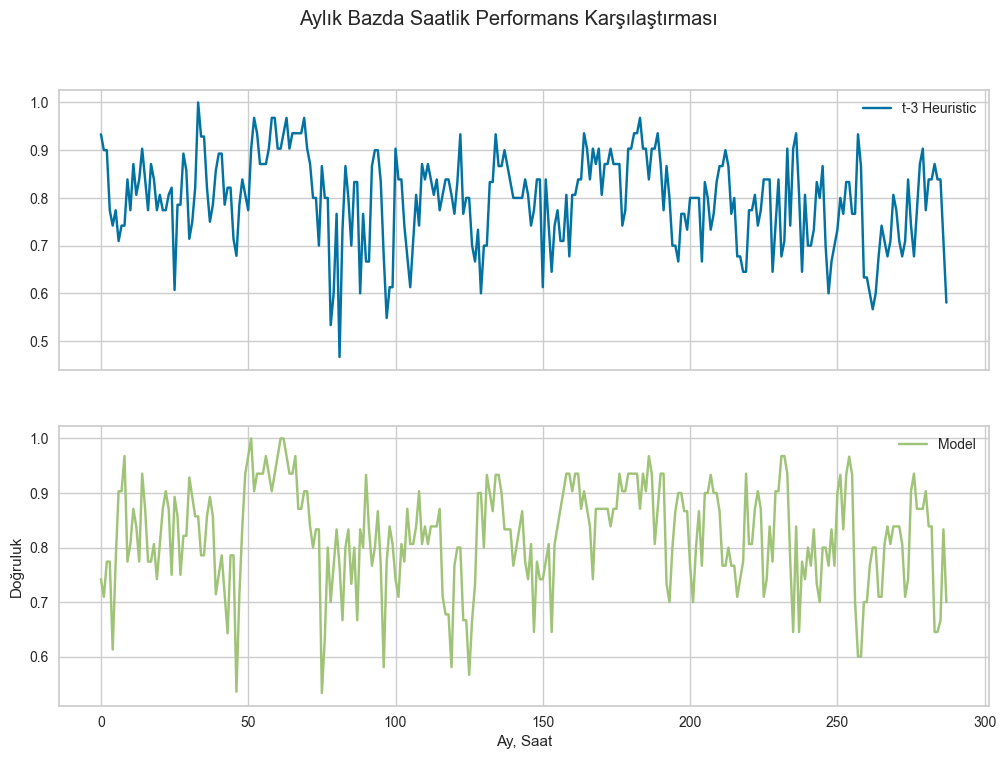

```python
# Saatlik doğruluk
hourly_accuracy_model = px.groupby("hour").apply(lambda x: (x["target_direction"] == x["prediction_label"]).mean())

# Aylık bazda saatlik doğruluk
monthly_hourly_accuracy_model = px.groupby(["decmonth", "hour"]).apply(lambda x: (x["target_direction"] == x["prediction_label"]).mean())

print("Modelin saatlik performansı:")
print(hourly_accuracy_model)

print("\nModelin aylık bazda saatlik performansı:")
print(monthly_hourly_accuracy_model.unstack())

# Grafikleri oluştur
import matplotlib.pyplot as plt

# Saatlik doğruluk grafiği
plt.figure(figsize=(12, 6))
plt.plot(hourly_accuracy, label="t-3 Heuristic")
plt.plot(hourly_accuracy_model, label="Model")
plt.xlabel("Saat")
plt.ylabel("Doğruluk")
plt.title("Saatlik Performans Karşılaştırması")
plt.legend()
plt.show()

# Aylık bazda saatlik doğruluk grafiği
monthly_hourly_accuracy_df = pd.DataFrame({"t-3 Heuristic": monthly_hourly_accuracy.unstack().values.flatten(),
                                           "Model": monthly_hourly_accuracy_model.unstack().values.flatten()})

monthly_hourly_accuracy_df.plot(subplots=True, layout=(2, 1), figsize=(12, 8), sharex=True, title="Aylık Bazda Saatlik Performans Karşılaştırması")
plt.xlabel("Ay, Saat")
plt.ylabel("Doğruluk")
plt.show()
```

Modelin performansını değerlendirdiğimizde, aylık saatlik bazda genel olarak daha iyi sonuçlar elde ettiğini gözlemleyebiliriz. Bu durum, modelin zaman içindeki değişimleri ve dönemsel etkileri daha iyi yakalayabilme yeteneğine işaret ediyor olabilir.

Sonuç olarak, modelimiz saatlik ve aylık saatlik performans açısından başarılı bir şekilde çalışmaktadır. Özellikle belirli saat aralıklarında daha iyi tahminler yaparak enerji piyasalarındaki dengesizlikleri önceden belirlemeye yardımcı olmaktadır.

```python
def yuzdeler(model, df, prediction_label, y):
    preds = predict_model(model, df)[[y, 'prediction_label', 'prediction_score']]
    son = pd.DataFrame()
    preds = preds[preds['prediction_label']==prediction_label]
    arange = np.arange(0.3, 1, 0.005)
    for i in arange:
        deneme = preds[preds['prediction_score']>=i]
        yuzde = round(accuracy_score(deneme[y], deneme['prediction_label']), 3)
        dicto = {'Thresh': i, 'Yüzde': yuzde, 'Len': len(deneme)}
        son = son.append(pd.DataFrame(dicto, index=[0]), ignore_index=True)
        son = son.dropna(axis=0)
    #son.to_csv(f"precs/{y}model_{prediction_label}.csv", index=False)
    return son.sort_values('Thresh', ascending=False)
```

Bu fonksiyon, bir sınıflandırma modelinin performansını farklı eşik (threshold) değerleri için yüzde doğruluk (accuracy) oranı olarak değerlendiren bir fonksiyondur. Fonksiyon, model, veri çerçevesi (df), tahmin edilen etiket (prediction_label) ve gerçek etiket (y) gibi argümanları alır.

Modelin ürettiği threshold ise softmax fonksiyonu ile üretilir. Softmax fonksiyonu, modelin çıktılarını olasılık dağılımına dönüştürmek için kullanılır. Enerji piyasalarının gelecekteki durumu için birden fazla sınıfı tahmin etmek istediğimizde, softmax fonksiyonu her sınıf için bir olasılık değeri atar. Bu olasılık değerleri, tahmin edilen sınıfların güven düzeyini gösterir ve tüm sınıfların olasılıkları toplamı 1'e eşittir.

```python
test_data['target_direction'].unique()
```

```
array(['ENERGY_SURPLUS', 'IN_BALANCE', 'ENERGY_DEFICIT'], dtype=object)
```

Bu çıktı, belirli bir tahmin etiketi için tahmin edilen olasılık eşiğine göre modelin doğruluğunu (accuracy) ve bu eşikteki örnek sayısını gösterir.

Bu tür analizler, belirli bir eşiğe göre modelin performansını değerlendirmenize ve en uygun eşiği belirlemenize olanak tanır. Ayrıca, belirli eşiklerde modelin ne kadar güvenilir olduğunu anlamanıza da yardımcı olur. Dikkate almanız gereken önemli bir nokta, daha yüksek eşik değerlerinde örnek sayısının azalması ve dolayısıyla modelin doğruluğunun daha az istikrarlı hale gelmesidir.

##### ENERGY_SURPLUS Sınıfı Tahmin Sonuçları İçin Güven Analizi

|  | Model | Accuracy | AUC | Recall | Prec. | F1 | Kappa | MCC |
| --- | --- | --- | --- | --- | --- | --- | --- | --- |
| 0 | Light Gradient Boosting Machine | 0.8222 | 0 | 0 | 0 | 0 | 0.3558 | 0.3746 |

|  | Thresh | Yüzde | Len |
| --- | --- | --- | --- |
| 93 | 0.765 | 1.000 | 1 |
| 92 | 0.760 | 0.667 | 3 |
| 91 | 0.755 | 0.857 | 7 |
| 90 | 0.750 | 0.909 | 11 |
| 89 | 0.745 | 0.929 | 14 |
| 88 | 0.740 | 0.882 | 17 |
| 87 | 0.735 | 0.852 | 27 |
| 86 | 0.730 | 0.784 | 37 |
| 85 | 0.725 | 0.795 | 44 |
| 84 | 0.720 | 0.778 | 54 |
| 83 | 0.715 | 0.778 | 63 |
| 82 | 0.710 | 0.781 | 73 |
| 81 | 0.705 | 0.780 | 82 |
| 80 | 0.700 | 0.791 | 91 |
| 79 | 0.695 | 0.792 | 96 |
| 78 | 0.690 | 0.810 | 105 |
| 77 | 0.685 | 0.809 | 110 |
| 76 | 0.680 | 0.817 | 120 |
| 75 | 0.675 | 0.820 | 128 |
| 74 | 0.670 | 0.822 | 135 |
| 73 | 0.665 | 0.803 | 147 |
| 72 | 0.660 | 0.803 | 157 |
| 71 | 0.655 | 0.799 | 169 |
| 70 | 0.650 | 0.804 | 179 |
| 69 | 0.645 | 0.799 | 189 |
| 68 | 0.640 | 0.804 | 199 |
| 67 | 0.635 | 0.798 | 218 |
| 66 | 0.630 | 0.789 | 232 |
| 65 | 0.625 | 0.778 | 252 |
| 64 | 0.620 | 0.749 | 283 |
| 63 | 0.615 | 0.736 | 307 |
| 62 | 0.610 | 0.718 | 337 |
| 61 | 0.605 | 0.715 | 355 |
| 60 | 0.600 | 0.721 | 376 |
| 59 | 0.595 | 0.718 | 397 |
| 58 | 0.590 | 0.713 | 436 |
| 57 | 0.585 | 0.720 | 457 |
| 56 | 0.580 | 0.717 | 481 |
| 55 | 0.575 | 0.707 | 502 |
| 54 | 0.570 | 0.700 | 527 |
| 53 | 0.565 | 0.698 | 550 |
| 52 | 0.560 | 0.694 | 566 |
| 51 | 0.555 | 0.685 | 590 |
| 50 | 0.550 | 0.678 | 627 |
| 49 | 0.545 | 0.675 | 650 |
| 48 | 0.540 | 0.674 | 668 |
| 47 | 0.535 | 0.672 | 690 |
| 46 | 0.530 | 0.657 | 722 |
| 45 | 0.525 | 0.649 | 740 |
| 44 | 0.520 | 0.644 | 772 |

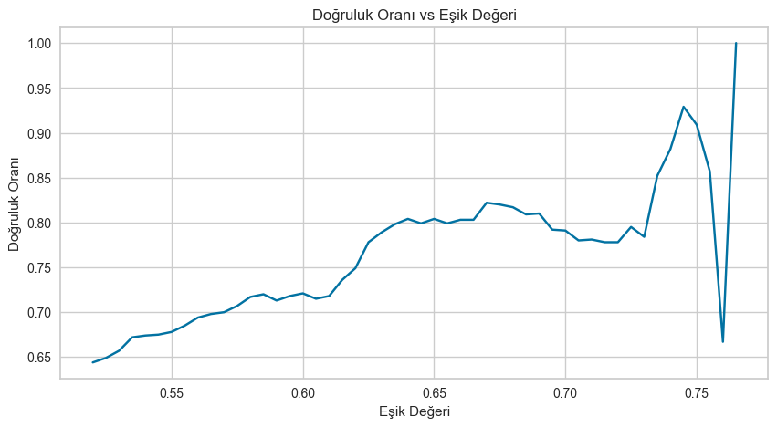

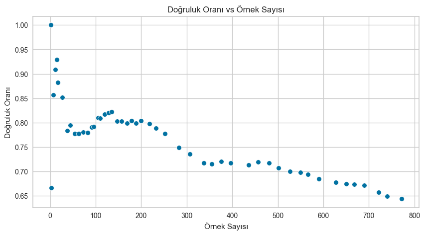

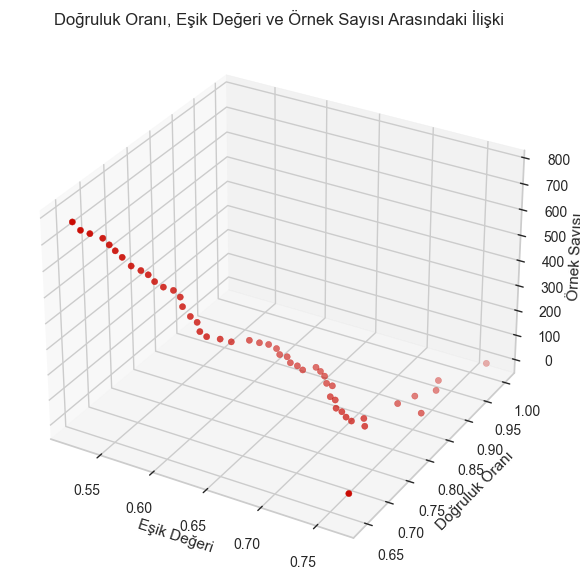

```python
import matplotlib.pyplot as plt
import seaborn as sns



sonuclar = yuzdeler(f,test_data,"ENERGY_SURPLUS","target_direction").head(50)

display(sonuclar)

# Doğruluk oranı (Yüzde) ve Eşik (Thresh) değerlerine göre bir çizgi grafiği oluşturma
plt.figure(figsize=(10, 5))
sns.lineplot(x='Thresh', y='Yüzde', data=sonuclar)
plt.title("Doğruluk Oranı vs Eşik Değeri")
plt.xlabel("Eşik Değeri")
plt.ylabel("Doğruluk Oranı")
plt.show()

# Doğruluk oranı (Yüzde) ve Örnek Sayısı (Len) arasındaki ilişkiyi gösteren bir dağılım grafiği oluşturma
plt.figure(figsize=(10, 5))
sns.scatterplot(x='Len', y='Yüzde', data=sonuclar)
plt.title("Doğruluk Oranı vs Örnek Sayısı")
plt.xlabel("Örnek Sayısı")
plt.ylabel("Doğruluk Oranı")
plt.show()

# Doğruluk oranı (Yüzde), Eşik (Thresh) değeri ve Örnek Sayısı (Len) arasındaki 3D ilişkiyi gösteren bir görsel
from mpl_toolkits.mplot3d import Axes3D

fig = plt.figure(figsize=(10, 7))
ax = fig.add_subplot(111, projection='3d')

x = sonuclar['Thresh']
y = sonuclar['Yüzde']
z = sonuclar['Len']

ax.scatter(x, y, z, c='r', marker='o')

ax.set_xlabel("Eşik Değeri")
ax.set_ylabel("Doğruluk Oranı")
ax.set_zlabel("Örnek Sayısı")
plt.title("Doğruluk Oranı, Eşik Değeri ve Örnek Sayısı Arasındaki İlişki")
plt.show()


import plotly.express as px

fig = px.scatter_3d(sonuclar, x='Thresh', y='Yüzde', z='Len', color='Thresh',
                    labels={'Thresh': 'Eşik Değeri', 'Yüzde': 'Doğruluk Oranı', 'Len': 'Örnek Sayısı'},
                    title="Doğruluk Oranı, Eşik Değeri ve Örnek Sayısı Arasındaki İlişki")

fig.show()
```

Bu çıktı, modelin enerji fazlası (ENERGY_SURPLUS) tahminleri için belirli eşik değerlerine göre başarı oranını ve o eşikteki örnek sayısını göstermektedir. Thresh (eşik) sütunu, tahmin olasılığına uygulanan eşik değerini temsil ederken, Yüzde sütunu eşik değerinin üzerindeki tahminlerin doğruluk oranını ve Len sütunu ise bu eşikteki örnek sayısını gösterir.

Öte yandan, eşik değerlerinin çok yüksek seçilmesi, modelin sadece çok yüksek güvene sahip olduğu örnekler için doğru tahminler yapabileceği anlamına gelir. Bu durum, tahminlerin gerçekleşme olasılığının daha düşük olduğu durumlarda modelin başarısını sınırlayabilir. Bu nedenle, doğru eşik değerini seçmek, doğru tahminler ile örnek sayısı arasında dikkatli bir denge kurmayı gerektirir.

##### ENERGY_DEFICIT Sınıfı Tahmin Sonuçları İçin Güven Analizi

|  | Model | Accuracy | AUC | Recall | Prec. | F1 | Kappa | MCC |
| --- | --- | --- | --- | --- | --- | --- | --- | --- |
| 0 | Light Gradient Boosting Machine | 0.8222 | 0 | 0 | 0 | 0 | 0.3558 | 0.3746 |

|  | Thresh | Yüzde | Len |
| --- | --- | --- | --- |
| 114 | 0.870 | 1.000 | 76 |
| 113 | 0.865 | 0.982 | 223 |
| 112 | 0.860 | 0.991 | 428 |
| 111 | 0.855 | 0.990 | 621 |
| 110 | 0.850 | 0.986 | 832 |
| 109 | 0.845 | 0.984 | 1014 |
| 108 | 0.840 | 0.985 | 1184 |
| 107 | 0.835 | 0.979 | 1337 |
| 106 | 0.830 | 0.969 | 1506 |
| 105 | 0.825 | 0.965 | 1672 |
| 104 | 0.820 | 0.960 | 1819 |
| 103 | 0.815 | 0.959 | 1968 |
| 102 | 0.810 | 0.957 | 2123 |
| 101 | 0.805 | 0.956 | 2276 |
| 100 | 0.800 | 0.953 | 2409 |
| 99 | 0.795 | 0.951 | 2555 |
| 98 | 0.790 | 0.947 | 2727 |
| 97 | 0.785 | 0.944 | 2884 |
| 96 | 0.780 | 0.942 | 3031 |
| 95 | 0.775 | 0.939 | 3178 |
| 94 | 0.770 | 0.937 | 3298 |
| 93 | 0.765 | 0.934 | 3428 |
| 92 | 0.760 | 0.933 | 3582 |
| 91 | 0.755 | 0.932 | 3698 |
| 90 | 0.750 | 0.930 | 3827 |
| 89 | 0.745 | 0.928 | 3966 |
| 88 | 0.740 | 0.924 | 4099 |
| 87 | 0.735 | 0.924 | 4222 |
| 86 | 0.730 | 0.922 | 4336 |
| 85 | 0.725 | 0.922 | 4449 |
| 84 | 0.720 | 0.923 | 4570 |
| 83 | 0.715 | 0.922 | 4653 |
| 82 | 0.710 | 0.919 | 4759 |
| 81 | 0.705 | 0.917 | 4852 |
| 80 | 0.700 | 0.916 | 4946 |
| 79 | 0.695 | 0.914 | 5028 |
| 78 | 0.690 | 0.913 | 5140 |
| 77 | 0.685 | 0.911 | 5246 |
| 76 | 0.680 | 0.910 | 5323 |
| 75 | 0.675 | 0.910 | 5410 |
| 74 | 0.670 | 0.909 | 5490 |
| 73 | 0.665 | 0.908 | 5580 |
| 72 | 0.660 | 0.905 | 5656 |
| 71 | 0.655 | 0.904 | 5767 |
| 70 | 0.650 | 0.903 | 5860 |
| 69 | 0.645 | 0.901 | 5922 |
| 68 | 0.640 | 0.899 | 6003 |
| 67 | 0.635 | 0.898 | 6081 |
| 66 | 0.630 | 0.898 | 6152 |
| 65 | 0.625 | 0.897 | 6219 |

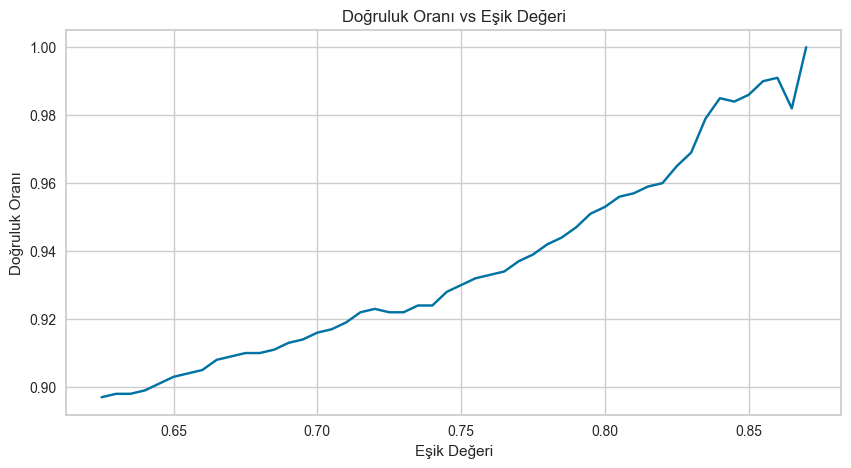

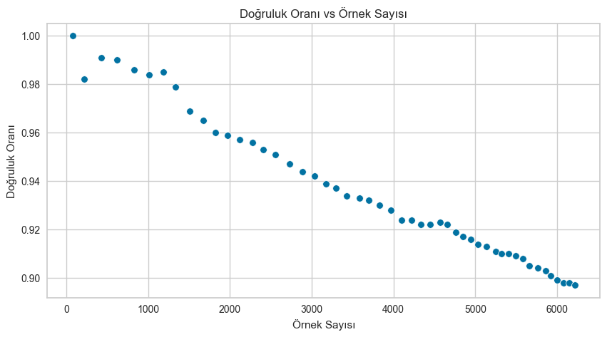

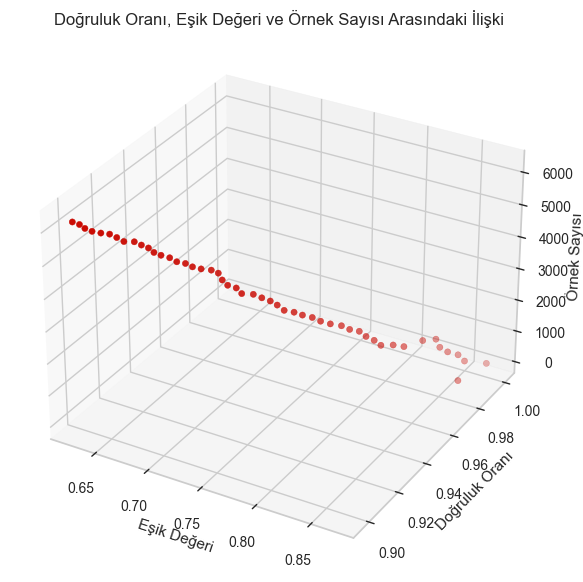

```python
import matplotlib.pyplot as plt
import seaborn as sns

sonuclar = yuzdeler(f,test_data,"ENERGY_DEFICIT","target_direction").head(50)

display(sonuclar)


# Doğruluk oranı (Yüzde) ve Eşik (Thresh) değerlerine göre bir çizgi grafiği oluşturma
plt.figure(figsize=(10, 5))
sns.lineplot(x='Thresh', y='Yüzde', data=sonuclar)
plt.title("Doğruluk Oranı vs Eşik Değeri")
plt.xlabel("Eşik Değeri")
plt.ylabel("Doğruluk Oranı")
plt.show()

# Doğruluk oranı (Yüzde) ve Örnek Sayısı (Len) arasındaki ilişkiyi gösteren bir dağılım grafiği oluşturma
plt.figure(figsize=(10, 5))
sns.scatterplot(x='Len', y='Yüzde', data=sonuclar)
plt.title("Doğruluk Oranı vs Örnek Sayısı")
plt.xlabel("Örnek Sayısı")
plt.ylabel("Doğruluk Oranı")
plt.show()

# Doğruluk oranı (Yüzde), Eşik (Thresh) değeri ve Örnek Sayısı (Len) arasındaki 3D ilişkiyi gösteren bir görsel
from mpl_toolkits.mplot3d import Axes3D

fig = plt.figure(figsize=(10, 7))
ax = fig.add_subplot(111, projection='3d')

x = sonuclar['Thresh']
y = sonuclar['Yüzde']
z = sonuclar['Len']

ax.scatter(x, y, z, c='r', marker='o')

ax.set_xlabel("Eşik Değeri")
ax.set_ylabel("Doğruluk Oranı")
ax.set_zlabel("Örnek Sayısı")
plt.title("Doğruluk Oranı, Eşik Değeri ve Örnek Sayısı Arasındaki İlişki")
plt.show()


import plotly.express as px

fig = px.scatter_3d(sonuclar, x='Thresh', y='Yüzde', z='Len', color='Thresh',
                    labels={'Thresh': 'Eşik Değeri', 'Yüzde': 'Doğruluk Oranı', 'Len': 'Örnek Sayısı'},
                    title="Doğruluk Oranı, Eşik Değeri ve Örnek Sayısı Arasındaki İlişki")

fig.show()
```

Bu çıktı, modelin enerji açığı (ENERGY_DEFICIT) tahminleri için belirli eşik değerlerine göre başarı oranını ve o eşikteki örnek sayısını göstermektedir. Thresh (eşik) sütunu, tahmin olasılığına uygulanan eşik değerini temsil ederken, Yüzde sütunu eşik değerinin üzerindeki tahminlerin doğruluk oranını ve Len sütunu ise bu eşikteki örnek sayısını gösterir.

Örnek sayısının (Len) ise eşik değeri düştükçe genel olarak arttığı gözlemlenmektedir. Bu durum, modelin enerji açığı tahminlerinde daha düşük olasılıklarla daha fazla örnek olduğunu gösterir.

Sonuç olarak, model enerji açığı tahminlerinde yüksek olasılıklı örneklerde daha başarılıdır ve eşik değeri düştükçe doğruluk oranı azalır. Bu analiz, modelin enerji açığı tahminlerinde belirli eşik değerlerine göre performansını değerlendirmemize ve hangi eşik değerlerinde modelin daha güvenilir olduğunu belirlememize yardımcı olur.

## 4.3ç Modelin Kaydedilmesi

Model, geliştirilecek uygulamalara entegre edilmek üzere kaydedilmiştir.

```python
save_model(f,'last_model')
```

```
Transformation Pipeline and Model Successfully Saved
```

```
(Pipeline(memory=FastMemory(location=C:\Users\Hakan\AppData\Local\Temp\joblib),
          steps=[('label_encoding',
                  TransformerWrapperWithInverse(exclude=None, include=None,
                                                transformer=LabelEncoder())),
                 ('numerical_imputer',
                  TransformerWrapper(exclude=None,
                                     include=['net', 'upRegulationZeroCoded',
                                              'upRegulationOneCoded',
                                              'downRegulationZeroCoded',
                                              'downRegulationOneCod...
                                 boosting_type='gbdt', class_weight=None,
                                 colsample_bytree=1.0, feature_fraction=0.5,
                                 importance_type='split', learning_rate=0.1,
                                 max_depth=-1, min_child_samples=81,
                                 min_child_weight=0.001, min_split_gain=0.4,
                                 n_estimators=10, n_jobs=-1, num_leaves=200,
                                 objective=None, random_state=1901,
                                 reg_alpha=0.4, reg_lambda=1, silent='warn',
                                 subsample=1.0, subsample_for_bin=200000,
                                 subsample_freq=0))],
          verbose=False),
 'last_model.pkl')
```

# 5. Sonuç

Bu çalışmada, enerji piyasalarında dengesizlik yönü tahmini için bir makine öğrenimi modeli geliştirdik. Dengesizlik yönü tahmini, enerji arzı ve talebi arasındaki dengesizliği önceden belirlemek için kullanılır ve enerji üreticileri, tüketicileri ve iletim sistem operatörleri için büyük öneme sahiptir.

Veri ön işleme adımlarında, eksik verileri doldurduk ve zaman serisi verisini uygun şekilde düzenledik. Özellik mühendisliği ile yeni özellikler oluşturarak modelin daha iyi tahminler yapabilmesine yardımcı olduk. Ardından, PyCaret kütüphanesi kullanarak çeşitli makine öğrenimi modellerini eğittik ve performanslarını değerlendirdik. LightGBM modeli, diğer modeller arasında en yüksek doğruluk oranını sağlayarak seçildi.

Tahmin olasılıklarının doğruluk oranlarına etkisini incelemek için, enerji fazlası ve enerji açığı tahminlerinde başarı oranlarını farklı eşik değerlerine göre değerlendirdik. Modelin yüksek olasılıklı tahminlerde daha başarılı olduğunu gözlemledik ve eşik değeri düştükçe doğruluk oranının azaldığını belirledik.

Sonuç olarak, bu çalışma enerji piyasalarında dengesizlik yönü tahmini için başarılı bir makine öğrenimi modeli geliştirmiştir. Model, t-3 heuristik yöntemine göre daha yüksek başarı oranlarına sahiptir ve belirli saat aralıklarında daha iyi performans sergilemektedir. Yüksek olasılıklı tahminlerde modelin daha güvenilir olduğu görülmüştür. Bu analizler, enerji sektörüne yönelik dengesizlik yönü tahminlerinin geliştirilmesine ve karar vericilere daha güvenilir bilgiler sunulmasına katkıda bulunabilir.